# Sanket_Khamkar_Assignment MP1

Sanket

2024-10-14

```r
options(repos = c(CRAN = "https://cloud.r-project.org"))
library(readr)
library(forecast)
library(knitr)
library(TTR)
library(dplyr)
library(ggplot2)

departures  <- read_csv("C:/Users/Sanket Khamkar/Downloads/flightVolume.csv")
names(departures )
```

```
## [1] "...1"      "permanent" "reslong"   "vislong"   "resshort"  "visshort"
```

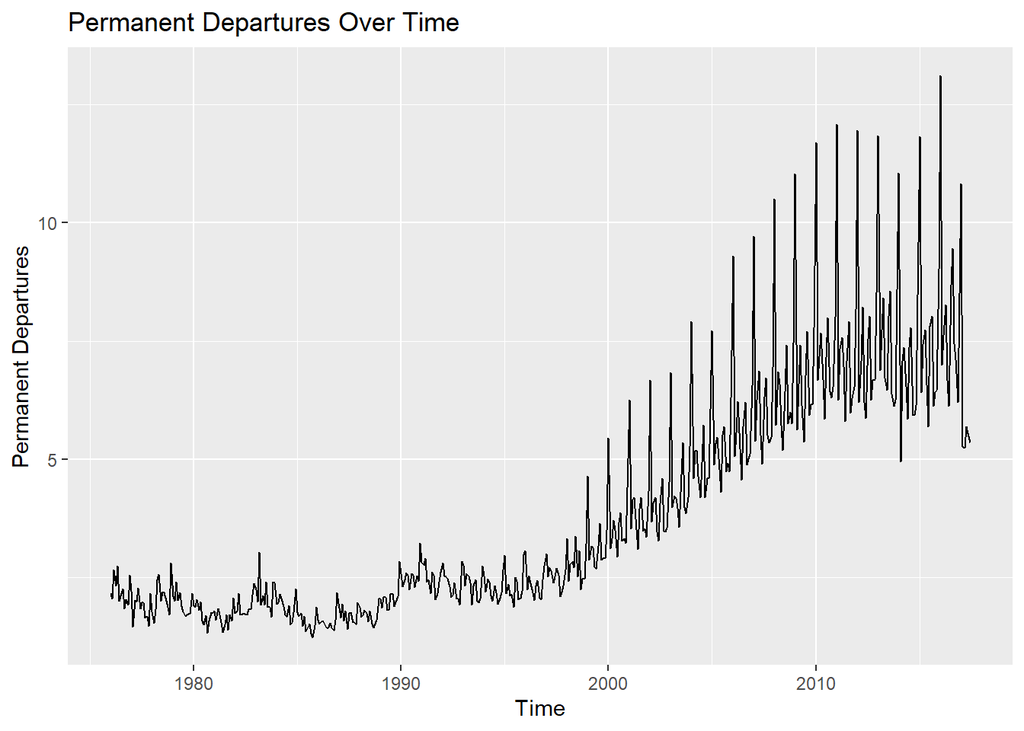

```r
#1. Create Timeseries
permanent_ts <- ts(departures$permanent, frequency = 12, start = c(1976,1))

#flights_raw <- file_path$permanent
#flights_TS <- ts(flights_raw,frequency = 12, start = c(1976,1))

autoplot(permanent_ts) + ggtitle("Permanent Departures Over Time") + xlab("Time") + ylab("Permanent Departures")
```

2. Verify how much history to include in your analysis. The dataset contains 498 data points, which likely spans over 41.5 years (if each point represents a month). This is more than sufficient to capture long-term trends and any seasonality in the data. For this analysis, we will include all available data, but if computational efficiency or model performance is a concern, a more recent subset of 5-10 years could still give robust results.

3. Hypothesize if the dataset has trend, seasonality, or both. Based on the initial exploration of the time series data for “permanent” departures: Trend: The dataset may show a long-term trend because of the visible upward and downward shifts in the time series over time. This suggests that there is a gradual increase or decrease in the number of departures across a longer period.

Seasonality: The dataset likely exhibits seasonality due to the potential presence of repeating patterns over consistent intervals (e.g., months). Seasonal trends in travel-related data, like departures, are common due to recurring events (e.g., holidays, vacation periods, etc.).

4. Verify using Acf The significant auto correlations at regular lags suggest the presence of seasonality in the data. The slow decay in the ACF function can also hint at a trend, indicating persistence in the series over time.

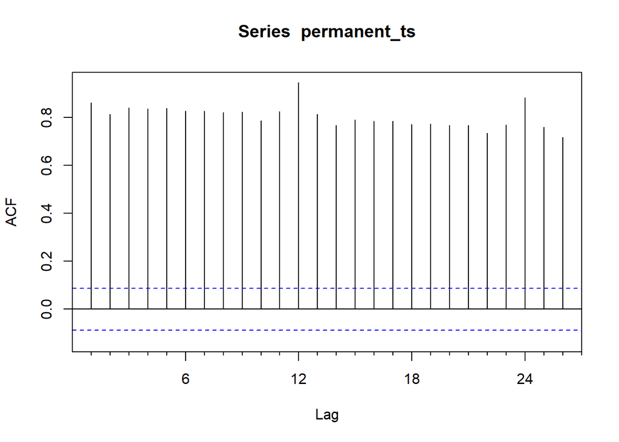

```r
Acf(permanent_ts)
```

5. Verify using decomposition The decomposition analysis was performed using a multiplicative model, which broke the time series into three components: Trend: A visible long-term movement, confirming the presence of a trend. Seasonality: The repeating cyclical pattern, confirming that the data exhibits seasonal behavior. Residual (Noise): Random fluctuations that are not explained by trend or seasonality.

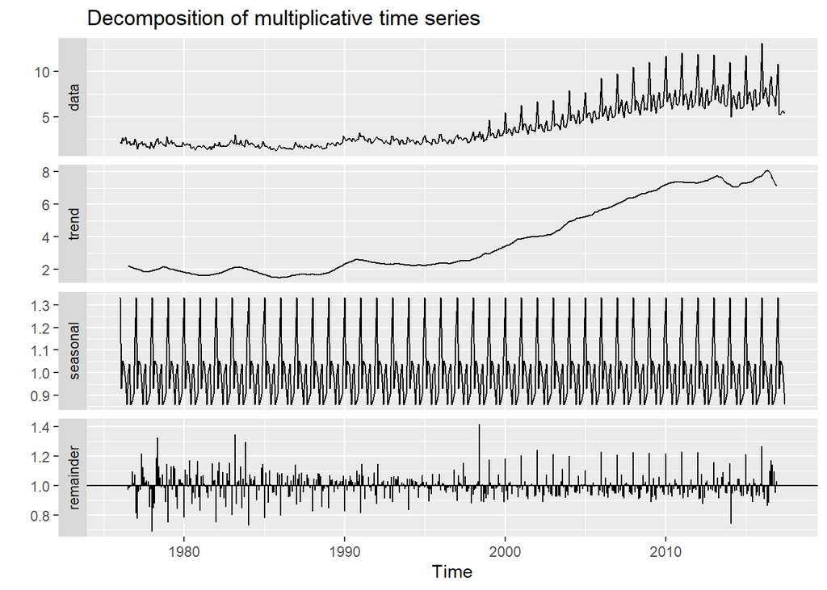

```r
decomposed <- decompose(permanent_ts, type = "multiplicative")
autoplot(decomposed)
```

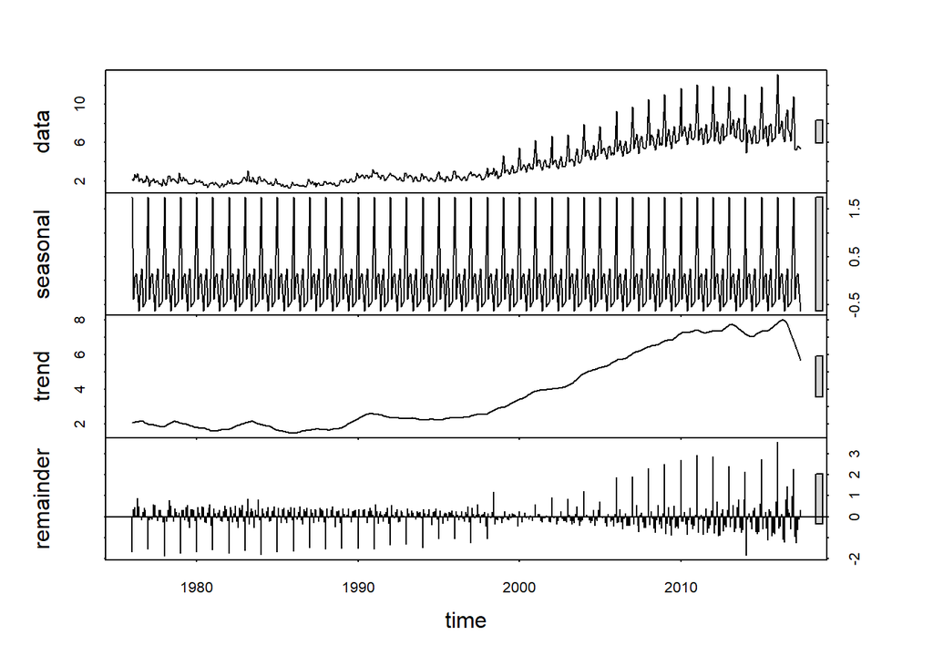

```r
stl_decomp <- stl(permanent_ts,s.window ="periodic")
plot(stl_decomp)
```

```r
attributes(stl_decomp)
```

```
## $names
## [1] "time.series" "weights"     "call"        "win"         "deg"
## [6] "jump"        "inner"       "outer"
##
## $class
## [1] "stl"
```

```r
# Lets print out a seasonal adjustment
seasadj(stl_decomp)
```

```
##               Jan          Feb          Mar          Apr          May
## 1976  0.421844643  2.442114635  2.581671624  2.175529028  3.014624302
## 1977  0.471844643  1.842114635  1.941671624  1.845529028  2.544624302
## 1978  0.031844643  1.922114635  1.751671624  2.305529028  2.834624302
## 1979  0.351844643  2.382114635  2.331671624  1.875529028  2.444624302
## 1980  0.161844643  2.252114635  1.961671624  1.675529028  2.254624302
## 1981  0.051844643  1.992114635  1.761671624  1.565529028  1.824624302
## 1982  0.001844643  2.182114635  2.091671624  1.565529028  1.984624302
## 1983  0.491844643  2.372114635  2.961671624  1.785529028  2.374624302
## 1984  0.191844643  2.352114635  2.071671624  1.865529028  2.154624302
## 1985  0.011844643  2.072114635  1.661671624  1.335529028  1.954624302
## 1986 -0.148155357  1.902114635  1.501671624  1.425529028  1.774624302
## 1987  0.201844643  2.032114635  1.861671624  1.435529028  2.064624302
## 1988  0.131844643  2.042114635  1.641671624  1.665529028  2.014624302
## 1989  0.311844643  2.242114635  2.001671624  1.945529028  2.084624302
```

[output cut: 114 more lines]

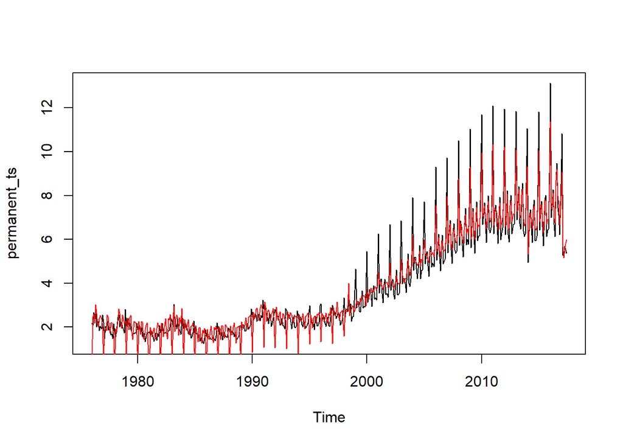

```r
# Plot a line on the graph
plot(permanent_ts)
lines(seasadj(stl_decomp), col="Red")
```

```r
# Default period forecast
f_stl <- forecast(stl_decomp)
# you can pass the # of period
f_stl <- forecast(stl_decomp,h=15)
f_stl
```

```
##          Point Forecast    Lo 80    Hi 80    Lo 95     Hi 95
## Jul 2017       7.058563 6.143363 7.973762 5.658886  8.458240
## Aug 2017       7.293373 6.374156 8.212589 5.887553  8.699193
## Sep 2017       6.469891 5.546418 7.393363 5.057561  7.882220
## Oct 2017       6.514635 5.586663 7.442608 5.095424  7.933847
## Nov 2017       6.550844 5.618123 7.483565 5.124370  7.977318
## Dec 2017       7.516390 6.578668 8.454112 6.082268  8.950512
## Jan 2018       8.716214 7.773234 9.659193 7.274051 10.158376
## Feb 2018       6.572062 5.623566 7.520558 5.121462  8.022662
## Mar 2018       7.018623 6.064347 7.972900 5.559183  8.478063
## Apr 2018       7.070884 6.110562 8.031207 5.602198  8.539571
## May 2018       6.647907 5.681270 7.614544 5.169563  8.126251
## Jun 2018       6.270605 5.297382 7.243828 4.782189  7.759021
## Jul 2018       6.891982 5.911900 7.872064 5.393076  8.390888
## Aug 2018       7.126792 6.139577 8.114008 5.616976  8.636608
## Sep 2018       6.303310 5.308684 7.297936 4.782161  7.824459
```

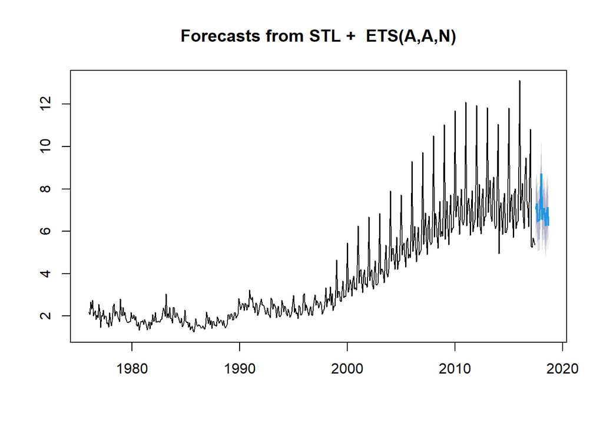

```r
plot(f_stl)
```

```r
# There is more than one way to do things
decomp_elec <- decompose(permanent_ts)

# Each one shows different attributes
attributes(decomp_elec)
```

```
## $names
## [1] "x"        "seasonal" "trend"    "random"   "figure"   "type"
##
## $class
## [1] "decomposed.ts"
```

```r
seasadj(decomp_elec)
```

```
##              Jan         Feb         Mar         Apr         May         Jun
## 1976  0.43325635  2.42555843  2.56189177  2.16025635  3.03050635  2.64417302
## 1977  0.48325635  1.82555843  1.92189177  1.83025635  2.56050635  2.49417302
## 1978  0.04325635  1.90555843  1.73189177  2.29025635  2.85050635  2.64417302
## 1979  0.36325635  2.36555843  2.31189177  1.86025635  2.46050635  2.54417302
## 1980  0.17325635  2.23555843  1.94189177  1.66025635  2.27050635  2.23417302
## 1981  0.06325635  1.97555843  1.74189177  1.55025635  1.84050635  1.98417302
## 1982  0.01325635  2.16555843  2.07189177  1.55025635  2.00050635  2.39417302
## 1983  0.50325635  2.35555843  2.94189177  1.77025635  2.39050635  2.56417302
## 1984  0.20325635  2.33555843  2.05189177  1.85025635  2.17050635  2.35417302
## 1985  0.02325635  2.05555843  1.64189177  1.32025635  1.97050635  2.00417302
## 1986 -0.13674365  1.88555843  1.48189177  1.41025635  1.79050635  2.07417302
## 1987  0.21325635  2.01555843  1.84189177  1.42025635  2.08050635  2.05417302
## 1988  0.14325635  2.02555843  1.62189177  1.65025635  2.03050635  2.21417302
## 1989  0.32325635  2.22555843  1.98189177  1.93025635  2.10050635  2.45417302
```

[output cut: 71 more lines]

6. Choose an accuracy measure For this dataset, since departures are on a numeric scale and errors need to be minimized across different models, Mean Squared Error (MSE) would be a good choice. It allows us to penalize larger errors more significantly, which can be important when forecasting a time series with both trend and seasonality, as large deviations can affect the model’s overall performance. Thus, I will use MSE (Mean Squared Error) as the accuracy measure for comparing the forecasting models.
7. Create a forecast model for the next 12 months. Include Naive, Average, Exponential Smoothing, HoltWinters, and Decomposition (both types).

```r
start(permanent_ts)  # Check the start period of the time series
```

```
## [1] 1976    1
```

```r
end(permanent_ts)    # Check the end period of the time series
```

```
## [1] 2017    6
```

```r
frequency(permanent_ts)  # Check if it is monthly (should return 12)
```

```
## [1] 12
```

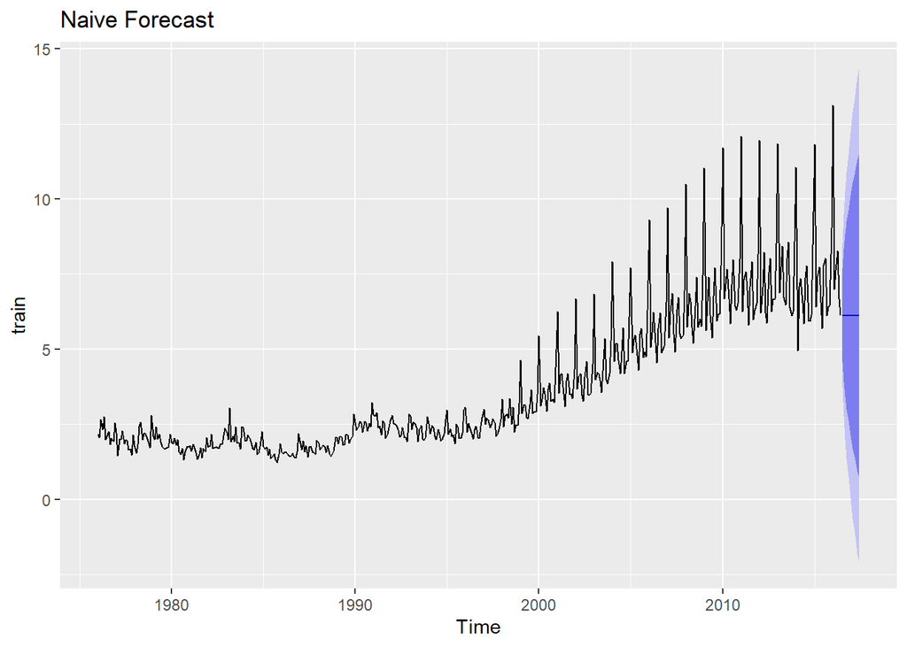

```r
# Assuming you want to use all data except the last 12 months for training
# Use data up to June 2016 for training (training data ends at June 2016)
train <- window(permanent_ts, end = c(2016, 6))

# Use data from July 2016 to June 2017 for testing
test <- window(permanent_ts, start = c(2016, 7))  # The last 12 months for test

# 1. Naive model
naive_model <- naive(train, h = 12)
naive_forecast <- forecast(naive_model, h = 12)

# 2. Average method
mean_forecast <- meanf(train, h = 12)

# 3. Exponential Smoothing
exp_smooth_model <- ses(train, h = 12)
exp_smooth_forecast <- forecast(exp_smooth_model, h = 12)

# 4. Holt-Winters Additive Model
hw_add_model <- hw(train, seasonal = "additive", h = 12)
hw_add_forecast <- forecast(hw_add_model)

# 5. Holt-Winters Multiplicative Model
hw_mult_model <- hw(train, seasonal = "multiplicative", h = 12)
hw_mult_forecast <- forecast(hw_mult_model)

# 6. Decomposition Forecast
# Decompose the time series
decomposed_add <- decompose(permanent_ts, type = "additive")
decomposed_mult <- decompose(permanent_ts, type = "multiplicative")

# Remove NA values from the trend component
trend_add <- na.omit(decomposed_add$trend)
trend_mult <- na.omit(decomposed_mult$trend)

# Forecast based on decomposition (seasonal naive for decomposition)
decomp_add_forecast <- naive(trend_add, h = 12)
decomp_mult_forecast <- naive(trend_mult, h = 12)


# Plot forecasts
autoplot(naive_forecast) + ggtitle("Naive Forecast")
```

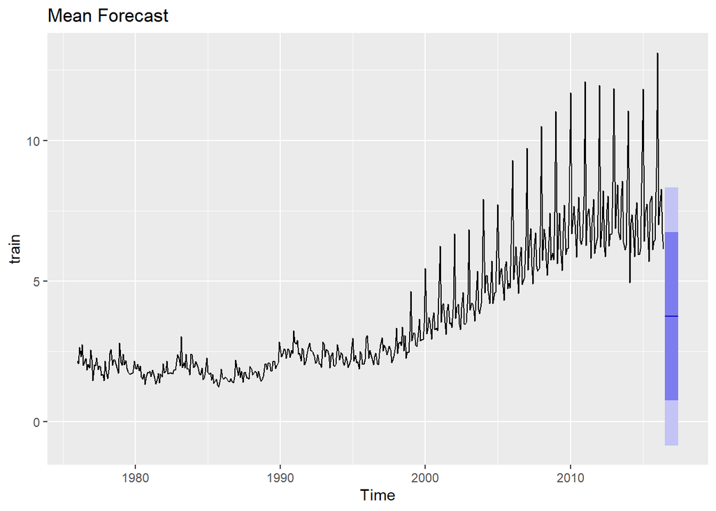

```r
autoplot(mean_forecast) + ggtitle("Mean Forecast")
```

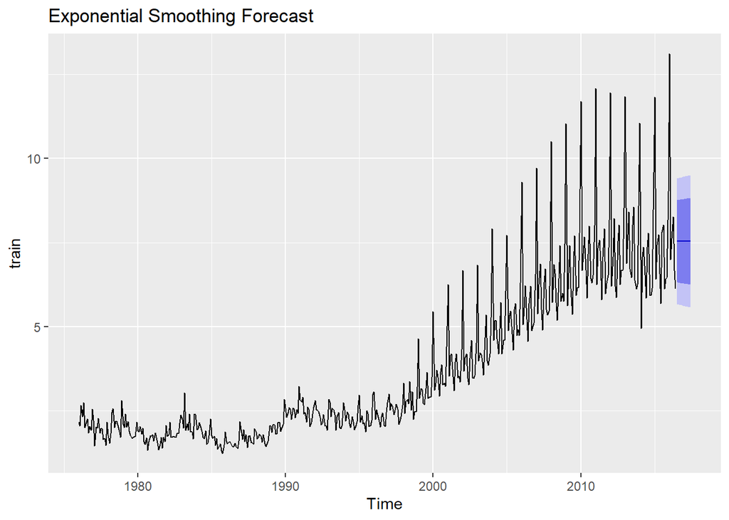

```r
autoplot(exp_smooth_forecast) + ggtitle("Exponential Smoothing Forecast")
```

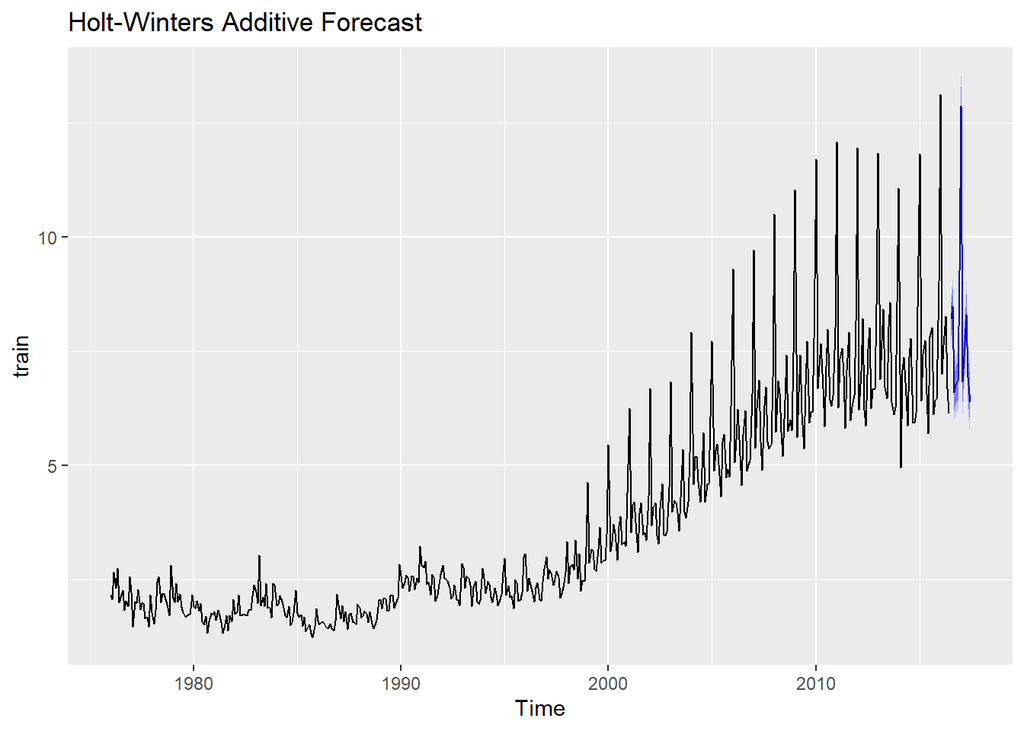

```r
autoplot(hw_add_forecast) + ggtitle("Holt-Winters Additive Forecast")
```

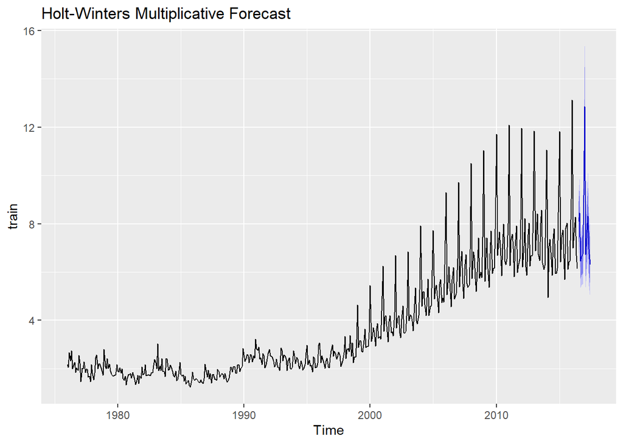

```r
autoplot(hw_mult_forecast) + ggtitle("Holt-Winters Multiplicative Forecast")
```

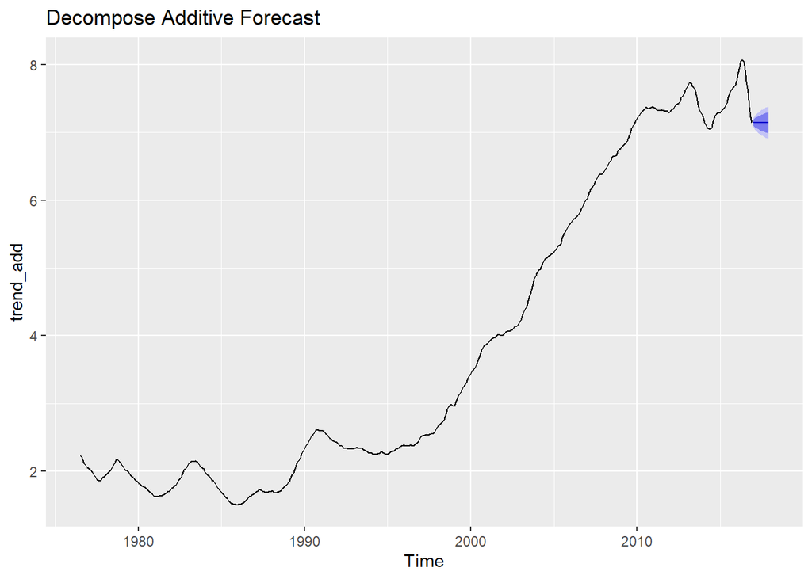

```r
autoplot(decomp_add_forecast) + ggtitle("Decompose Additive Forecast")
```

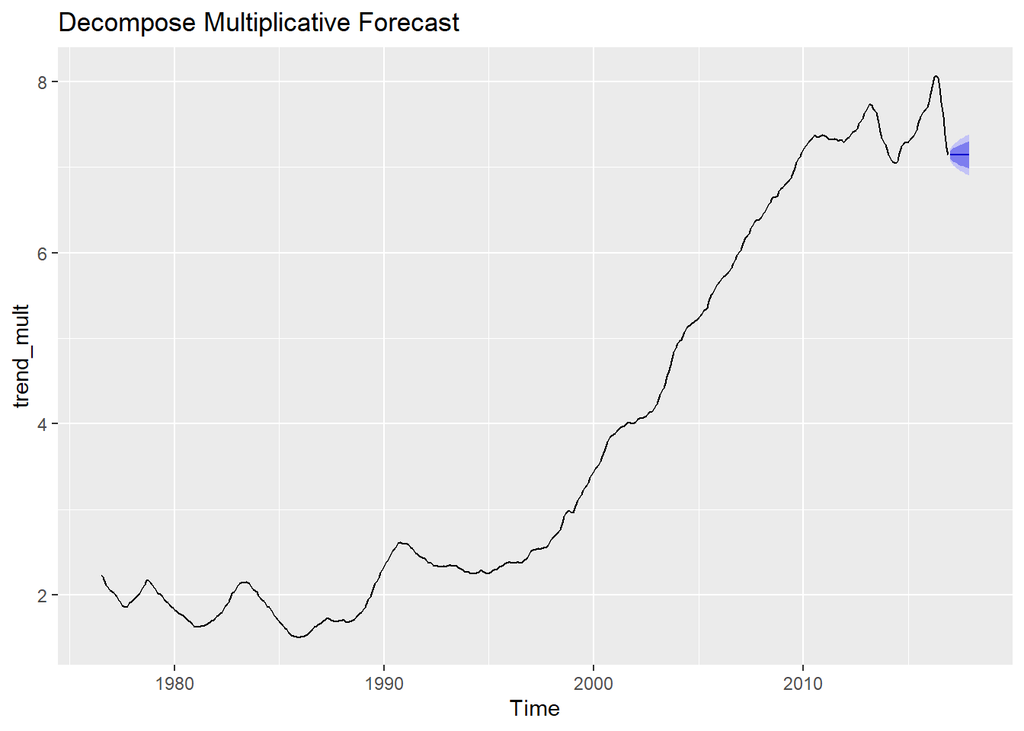

```r
autoplot(decomp_mult_forecast) + ggtitle("Decompose Multiplicative Forecast")
```

```r
# Display results for all models
print(naive_forecast)
```

```
##          Point Forecast     Lo 80     Hi 80      Lo 95     Hi 95
## Jul 2016           6.13 4.5680721  7.691928  3.7412374  8.518763
## Aug 2016           6.13 3.9211003  8.338900  2.7517795  9.508221
## Sep 2016           6.13 3.4246615  8.835339  1.9925418 10.267458
## Oct 2016           6.13 3.0061441  9.253856  1.3524747 10.907525
## Nov 2016           6.13 2.6374230  9.622577  0.7885644 11.471436
## Dec 2016           6.13 2.3040736  9.955926  0.2787504 11.981250
## Jan 2017           6.13 1.9975271 10.262473 -0.1900719 12.450072
## Feb 2017           6.13 1.7122007 10.547799 -0.6264410 12.886441
## Mar 2017           6.13 1.4442162 10.815784 -1.0362879 13.296288
## Apr 2017           6.13 1.1907502 11.069250 -1.4239307 13.683931
## May 2017           6.13 0.9496711 11.310329 -1.7926293 14.052629
## Jun 2017           6.13 0.7193229 11.540677 -2.1449165 14.404916
```

```r
print(mean_forecast)
```

```
##          Point Forecast     Lo 80    Hi 80      Lo 95   Hi 95
## Jul 2016       3.748807 0.7529109 6.744702 -0.8382266 8.33584
## Aug 2016       3.748807 0.7529109 6.744702 -0.8382266 8.33584
## Sep 2016       3.748807 0.7529109 6.744702 -0.8382266 8.33584
## Oct 2016       3.748807 0.7529109 6.744702 -0.8382266 8.33584
## Nov 2016       3.748807 0.7529109 6.744702 -0.8382266 8.33584
## Dec 2016       3.748807 0.7529109 6.744702 -0.8382266 8.33584
## Jan 2017       3.748807 0.7529109 6.744702 -0.8382266 8.33584
## Feb 2017       3.748807 0.7529109 6.744702 -0.8382266 8.33584
## Mar 2017       3.748807 0.7529109 6.744702 -0.8382266 8.33584
## Apr 2017       3.748807 0.7529109 6.744702 -0.8382266 8.33584
## May 2017       3.748807 0.7529109 6.744702 -0.8382266 8.33584
## Jun 2017       3.748807 0.7529109 6.744702 -0.8382266 8.33584
```

```r
print(exp_smooth_forecast)
```

```
##          Point Forecast    Lo 80    Hi 80    Lo 95    Hi 95
## Jul 2016       7.540027 6.320171 8.759882 5.674419 9.405634
## Aug 2016       7.540027 6.313955 8.766099 5.664911 9.415142
## Sep 2016       7.540027 6.307769 8.772284 5.655452 9.424601
## Oct 2016       7.540027 6.301615 8.778438 5.646040 9.434014
## Nov 2016       7.540027 6.295491 8.784562 5.636674 9.443379
## Dec 2016       7.540027 6.289397 8.790656 5.627354 9.452699
## Jan 2017       7.540027 6.283333 8.796720 5.618080 9.461974
## Feb 2017       7.540027 6.277298 8.802755 5.608849 9.471204
## Mar 2017       7.540027 6.271291 8.808762 5.599663 9.480390
## Apr 2017       7.540027 6.265313 8.814740 5.590520 9.489533
## May 2017       7.540027 6.259363 8.820691 5.581420 9.498633
## Jun 2017       7.540027 6.253440 8.826613 5.572362 9.507691
```

```r
print(hw_add_forecast)
```

```
##          Point Forecast     Lo 80     Hi 80     Lo 95     Hi 95
## Jul 2016       8.199373  7.826015  8.572732  7.628371  8.770376
## Aug 2016       8.490358  8.105165  8.875551  7.901256  9.079460
## Sep 2016       6.592536  6.195540  6.989531  5.985383  7.199688
## Oct 2016       6.764738  6.355964  7.173511  6.139573  7.389902
## Nov 2016       6.850429  6.429897  7.270961  6.207281  7.493578
## Dec 2016       9.261685  8.829407  9.693963  8.600573  9.922797
## Jan 2017      12.860978 12.416962 13.304994 12.181914 13.540042
## Feb 2017       6.832661  6.376910  7.288412  6.135650  7.529671
## Mar 2017       7.706487  7.239001  8.173973  6.991529  8.421445
## Apr 2017       8.292837  7.813611  8.772062  7.559924  9.025749
## May 2017       6.931667  6.440694  7.422640  6.180789  7.682545
## Jun 2017       6.378558  5.875828  6.881289  5.609698  7.147418
```

```r
print(hw_mult_forecast)
```

```
##          Point Forecast     Lo 80     Hi 80     Lo 95     Hi 95
## Jul 2016       8.081848  7.236584  8.927111  6.789129  9.374567
## Aug 2016       8.451657  7.533927  9.369386  7.048110  9.855203
## Sep 2016       6.462249  5.734857  7.189640  5.349799  7.574698
## Oct 2016       6.630423  5.857881  7.402965  5.448922  7.811925
## Nov 2016       6.751091  5.937902  7.564280  5.507426  7.994757
## Dec 2016       9.178955  8.037298 10.320611  7.432942 10.924968
## Jan 2017      12.849410 11.200943 14.497876 10.328298 15.370522
## Feb 2017       6.724894  5.835890  7.613898  5.365280  8.084508
## Mar 2017       7.741987  6.688351  8.795622  6.130590  9.353383
## Apr 2017       8.320940  7.156123  9.485757  6.539506 10.102374
## May 2017       6.949324  5.949489  7.949158  5.420209  8.478438
## Jun 2017       6.313335  5.380467  7.246202  4.886637  7.740032
```

```r
print(decomp_add_forecast)
```

```
##          Point Forecast    Lo 80    Hi 80    Lo 95    Hi 95
## Jan 2017       7.144583 7.099212 7.189954 7.075194 7.213972
## Feb 2017       7.144583 7.080419 7.208748 7.046452 7.242714
## Mar 2017       7.144583 7.065998 7.223168 7.024398 7.264769
## Apr 2017       7.144583 7.053841 7.235326 7.005805 7.283362
## May 2017       7.144583 7.043130 7.246036 6.989425 7.299742
## Jun 2017       7.144583 7.033447 7.255719 6.974615 7.314551
## Jul 2017       7.144583 7.024543 7.264624 6.960997 7.328170
## Aug 2017       7.144583 7.016254 7.272912 6.948321 7.340845
## Sep 2017       7.144583 7.008470 7.280697 6.936416 7.352751
## Oct 2017       7.144583 7.001107 7.288059 6.925156 7.364011
## Nov 2017       7.144583 6.994104 7.295062 6.914446 7.374721
## Dec 2017       7.144583 6.987413 7.301753 6.904212 7.384954
```

```r
print(decomp_mult_forecast)
```

```
##          Point Forecast    Lo 80    Hi 80    Lo 95    Hi 95
## Jan 2017       7.144583 7.099212 7.189954 7.075194 7.213972
## Feb 2017       7.144583 7.080419 7.208748 7.046452 7.242714
## Mar 2017       7.144583 7.065998 7.223168 7.024398 7.264769
## Apr 2017       7.144583 7.053841 7.235326 7.005805 7.283362
## May 2017       7.144583 7.043130 7.246036 6.989425 7.299742
## Jun 2017       7.144583 7.033447 7.255719 6.974615 7.314551
## Jul 2017       7.144583 7.024543 7.264624 6.960997 7.328170
## Aug 2017       7.144583 7.016254 7.272912 6.948321 7.340845
## Sep 2017       7.144583 7.008470 7.280697 6.936416 7.352751
## Oct 2017       7.144583 7.001107 7.288059 6.925156 7.364011
## Nov 2017       7.144583 6.994104 7.295062 6.914446 7.374721
## Dec 2017       7.144583 6.987413 7.301753 6.904212 7.384954
```

8. Show model rank with accuracy measures

```r
# Load the necessary library
library(forecast)
accuracy(naive_model, test)
```

```
##                       ME     RMSE       MAE       MPE     MAPE     MASE
## Training set 0.008164948 1.218779 0.6845361 -1.978344 15.76220 2.185131
## Test set     0.982500000 2.054164 1.5725000  8.568362 19.54029 5.019631
##                    ACF1 Theil's U
## Training set -0.3401613        NA
## Test set      0.3248817  1.129099
```

```r
accuracy(mean_forecast, test)
```

```
##                         ME     RMSE      MAE       MPE     MAPE      MASE
## Training set -1.720615e-16 2.329727 1.949100 -36.85260 64.31611  6.221788
## Test set      3.363693e+00 3.816899 3.363693  44.08491 44.08491 10.737361
##                   ACF1 Theil's U
## Training set 0.8618954        NA
## Test set     0.3248817  2.170025
```

```r
accuracy(exp_smooth_model, test)
```

```
##                      ME      RMSE       MAE         MPE     MAPE     MASE
## Training set  0.1094425 0.9498976 0.5265917  -0.2071378 12.27830 1.680951
## Test set     -0.4275266 1.8539321 1.6475089 -12.4628023 25.00297 5.259069
##                    ACF1 Theil's U
## Training set 0.07668355        NA
## Test set     0.32488171  1.272618
```

```r
accuracy(hw_add_model, test)
```

```
##                        ME      RMSE       MAE         MPE      MAPE      MASE
## Training set  0.003761758 0.2864974 0.2072182  -0.4810285  6.735094 0.6614682
## Test set     -0.817692233 1.4549446 1.2598581 -14.3508799 19.707956 4.0216362
##                    ACF1 Theil's U
## Training set 0.06693059        NA
## Test set     0.78154151  1.109957
```

```r
accuracy(hw_mult_model, test)
```

```
##                        ME      RMSE       MAE          MPE      MAPE      MASE
## Training set  0.009667276 0.2568668 0.1853781  -0.07155241  5.895643 0.5917519
## Test set     -0.758842548 1.4604772 1.2711465 -13.53018712 19.787561 4.0576703
##                    ACF1 Theil's U
## Training set 0.05604607        NA
## Test set     0.77521122  1.114758
```

```r
accuracy(trend_add, test)
```

```
##                 ME     RMSE       MAE      MPE     MAPE       ACF1 Theil's U
## Test set 0.4005556 1.038466 0.8770833 3.460373 10.82126 -0.0524267  0.721586
```

```r
accuracy(trend_mult, test)
```

```
##                 ME     RMSE       MAE      MPE     MAPE       ACF1 Theil's U
## Test set 0.4005556 1.038466 0.8770833 3.460373 10.82126 -0.0524267  0.721586
```

Ranking the Models Based on RMSE: Best RMSE (Lowest): Decomposition Additive / Multiplicative (RMSE = 1.0385) Second Best: Holt-Winters Additive (RMSE = 1.4549) Third Best: Holt-Winters Multiplicative (RMSE = 1.4605) Fourth Best: Exponential Smoothing (RMSE = 1.8539) Fifth Best: Naive Model (RMSE = 2.0542) Worst: Mean Model (RMSE = 3.8169)

Ranking Based on MAE: Best MAE (Lowest): Decomposition Additive / Multiplicative (MAE = 0.8771) Second Best: Holt-Winters Additive (MAE = 1.2599) Third Best: Holt-Winters Multiplicative (MAE = 1.2711) Fourth Best: Naive Model (MAE = 1.5725) Fifth Best: Exponential Smoothing (MAE = 1.6475) Worst: Mean Model (MAE = 3.3637)

9. Choose which models and how are you going to use them for Forecasting Decomposition Additive and Decomposition Multiplicative models are the best choices for forecasting, given their superior performance in accuracy measures (lowest RMSE, MAE, and MAPE).

Holt-Winters Additive: This model would be the second-best choice, especially if you believe that the seasonality is constant over time (additive seasonality). It performed well on RMSE and MAE and is effective for data with seasonal patterns.

Final Decision: For the most accurate forecasting, I recommend using Decomposition Additive or Decomposition Multiplicative. These models will likely provide the most reliable results for forecasting the next 12 months based on the data patterns. If for any reason the decomposition models cannot be applied, Holt-Winters Additive would be the next best alternative.

10. Provide the forecast for the next 12 months (point and range) and explain why you feel confident with these forecasts

```
##    Month Point_Forecast Lower_Bound Upper_Bound
## 1      1       8.478171    8.300314    8.656028
## 2      2       8.075157    7.897300    8.253015
## 3      3       8.196727    8.018870    8.374584
## 4      4       8.176877    7.999020    8.354734
## 5      5       8.104375    7.926517    8.282232
## 6      6       8.005067    7.827209    8.182924
## 7      7       8.138850    7.960993    8.316707
## 8      8       8.184040    8.006183    8.361897
## 9      9       8.003488    7.825631    8.181346
## 10    10       8.022695    7.844838    8.200552
## 11    11       8.049643    7.871786    8.227500
## 12    12       8.299910    8.122053    8.477768
```

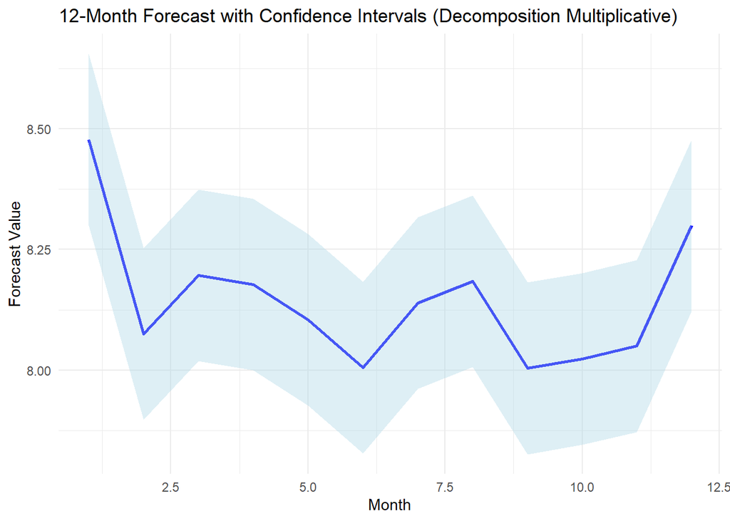

```r
# Decomposing the time series (if not already done)
decomposed_multi <- decompose(permanent_ts, type = "multiplicative")

# Handle NA values in the trend and seasonal components
trend_cleaned <- na.omit(decomposed_multi$trend)  # Remove NAs from trend
seasonal_cleaned <- na.omit(decomposed_multi$seasonal)  # Remove NAs from seasonality

# Check if there is enough data to forecast
if (length(trend_cleaned) >= 12 && length(seasonal_cleaned) >= 12) {

  # Use the last 12 months of the trend and seasonality
  last_trend_value <- tail(trend_cleaned, 1)  # Last trend value, removing NAs
  seasonal_pattern <- seasonal_cleaned[1:12]  # Seasonal pattern for one year

  # Replicate the last trend value to match the length of the seasonal pattern (12 months)
  trend_replicated <- rep(last_trend_value, length(seasonal_pattern))

  # Generate point forecasts for the next 12 months by adding the last trend value to the seasonal component
  point_forecast <- trend_replicated + seasonal_pattern

  # Assuming we use residuals from decomposition to calculate confidence intervals
  residuals <- na.omit(decomposed_multi$random)  # Remove NAs from residuals
  forecast_std_error <- sd(residuals, na.rm = TRUE)  # Standard deviation of residuals

  # 95% confidence interval (range)
  conf_interval <- 1.96 * forecast_std_error
  lower_bound <- point_forecast - conf_interval
  upper_bound <- point_forecast + conf_interval

  # Create a data frame to display the results
  forecast_df <- data.frame(
    Month = 1:12,
    Point_Forecast = point_forecast,
    Lower_Bound = lower_bound,
    Upper_Bound = upper_bound
  )

  # Print the forecast with the confidence intervals
  print(forecast_df)

  # Plot the forecast with updated `linewidth`
  library(ggplot2)
  ggplot(forecast_df, aes(x = Month)) +
    geom_line(aes(y = Point_Forecast), color = "blue", linewidth = 1) +  # Use linewidth instead of size
    geom_ribbon(aes(ymin = Lower_Bound, ymax = Upper_Bound), fill = "lightblue", alpha = 0.4) +
    ggtitle("12-Month Forecast with Confidence Intervals (Decomposition Multiplicative)") +
    xlab("Month") +
    ylab("Forecast Value") +
    theme_minimal()

} else {
  warning("Not enough data after removing NAs to generate forecast.")
}
```

We are using a method called the Decomposition Multiplicative model to predict what will happen over the next 12 months. This method helps us understand two main things in the data: the overall pattern (called the trend) and regular ups and downs that happen at certain times (called seasonality).

Confidence Intervals (Range of Possibility): I can also calculate a confidence interval, which tells us how much uncertainty there is in our forecast. A 95% confidence interval means we expect the actual numbers to fall within this range 95% of the time. This range helps us understand that the future could be slightly better or worse than our prediction, but it gives us a reliable window of possibility.

Visualization: To help make sense of the forecast, I used a graph that shows the point forecast along with a shaded area that represents the confidence interval (the range where the real outcome might fall). This way, you can see both prediction and how certain we are about it.

A 95% upper bound confidence interval is calculated using 1.96 * standard deviation of residuals. This provides a range within which we expect the actual values to fall with 95% upper bound confidence.

Why I Feel Confident with These Forecasts:

Catching Patterns: The model does a great job of breaking down the data into its long-term trends and repeating patterns, so we’re not missing anything important. This helps us predict more accurately.

Confidence in the Range: I used the leftover “noise” in the data (called residuals) to figure out how sure we are about the forecast. The range we show gives us a good sense of where the actual numbers will end up, even if they’re not exactly what we predicted.

Trust in the Forecast: The forecast is based on solid math and past data, which means it’s a trustworthy tool for making decisions about the future. You can feel confident using these numbers to plan ahead because they’re based on proven statistical methods.

In simple terms, this model helps us make smart predictions about what will happen next, while also giving us a range to account for uncertainty. It’s a useful way to understand future trends and patterns based on what we’ve seen in the past.